# Programming in R: coursework

Chris Clements

2023

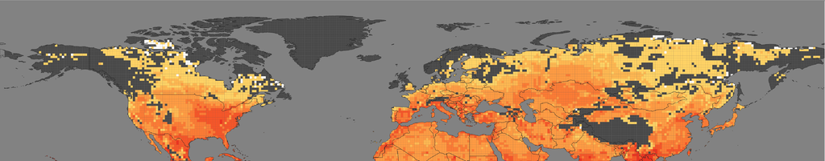

# 1 Background

Climatic change is leading to the loss of biodiversity globally. Its effects are multifaceted: it can cause mortality of individuals through extreme weather events such as drought or flash floods, but can also detrimentally affect the health of individuals through changes such as reduced food availability leading to increased intraspecific competition for resources. These indirect effects are more subtle, but perhaps more interesting, as they can be detected in long term data as changes in the body condition of individuals through time. Detecting such subtle changes in the health of individuals (and ultimately populations) is one of the great advantages of collecting long-term data which spans many years and many individuals, and something which you would miss if you collected data only for a few years. But to do this we need to reliably analyze these long term data to see whether such trends are apparent.

# 2 The problem

Previous work has shown that the mean strength of the North Atlantic oscillation between June and August, a major weather phenomenon that drives around 40% of the observed variation in atmospheric sea-level pressure between 15–90◦N and 110◦W–70◦E, significantly affects the survival of individuals of the rare Soay Sheep ( *Ovis aries* ).

It has been proposed that this change in survival is driven by changes in the mean body mass of individuals, as smaller individuals have been shown to have higher mortality rates. However, there has been no work investigating whether there is an effect of the summer NAO (sNAO) on body mass, or indeed what other factors determine body mass or the relationship between body mass and NAO.

# 3 The data

Data have been collected between 1980 and 2020 on the masses of individuals (in KG). Individuals have been caught once per year, weighed, sexed, and the number of offspring they have had been recorded. Your task is to analyse these data to determine what are the determinants of body mass in this species.

## 3.1 Structure

You have each been given two data sets, one on the strength of the NAO across the study period, and another on the masses of sheep during that period. The NAO data have the following columns:

- Year - the year the recording was taken in
- January - December - the recorded strength of the NAO in each month

The sheep mass data differ between students, and may include some or all of the following columns:

- age - the age of the indivdual when the mass (in KG) was recorded
- sex - whether the individual is a male or female
- n_baby - the number of babies an individual had in a given year
- pop_size - the size of the population in a given year
- ID - a unique ID identifying each individual
- year - the year a measurement was taken in
- site - which site a mass measurement was taken in
- observer - who took the measurement

## 3.2 Availability

Each of you has two data sets, one containing the data on body mass of the sheep, and a second containing the recorded values of the NAO over the period of the study. Both of these files are available to download from the R coursework data repository on github [here](https://github.com/chrit88/R-coursework-data.git). Please ensure you download the data which corresponds to your UoB username (e.g. if your username is ‘xm21121’ you data would be ‘mass_xm21121’ and ‘NAO_xm21121’).

# 4 Task

You need to demonstrate what the determinants of body mass in this population of Soay sheep is, using any statistical modelling frameworks you think are appropriate. You must write a report showing:

1. how you read, manipulated (where appropriate), and visualized the data you are working with
2. what statistical tools you used to analyse these data and why these tools are justified (considering things like model structure and error distribution)
3. what determines the mass of Soay sheep (including any evidence to support your claims)

Please ensure you show all of the code you used to make these calculations and graphics, and note that the data provided to each of you is different to everyone else’s data, both in terms of the structure and what (if any) effects may be significant.

This report should be written in the style of the workbooks you are familiar with from the R course, and must contain no more than 500 words (not including any code or code comments). The report should demonstrate the skills and best practices you have learnt over the Programming in R course: demonstrating your ability to write precise and concise R code, and to present your results in a format which other people can understand and check (you may want to use the Rmarkdown workbooks from the course as inspiration). Where appropriate you should include and interpret the outputs of statistical models so the reader can judge whether you have fitted appropriate models and whether your conclusions are justified.

# 5 Submission

Submission should be in the form of a .zip document containing both the rmarkdown file and the html output.

The deadline for this coursework is the **11 January 2023 at 13.00 h.**.